# Assignment 3 VIS

Ryan Johnson

9/27/2020

## Description

I have assembled a set of four layers of Austin information from the City of Austin and State of Texas open data portals. This set includes two point layers (the locations of Capital Metro transit stops, and the locations of developments which include at least one unit of affordable housing) and two polygon layers (a map of Austin city council district boundaries, and a map of areas zoned for Planned Unit Developments by the City of Austin). The PUD layer was created by downloading a shapefile of Austin’s entire zoning map, then filtering it to include only those areas with a PUD designation.

I will perform spatial analysis on these layers to describe the six metrics indicated below.

Source links: https://data.austintexas.gov/ & https://data.texas.gov/

**Layers:**

A. CoA affordable housing inventory (point)

```r
Afford <- Afford %>%
  filter(Total_Affo > 0)
```

B. Capital Metro transit stops (point) - includes only bus/train stops within Austin proper

C. CoA zoning map (polygon) - filtered to include only those parcels zoned for Planned Unit Development (PUD)

D. CoA council districts (polygon)

**Metrics:**

1. The number and proportion of A points within a specified distance of B points,
2. Average distance b/w A points and their nearest respective B points,
3. Number and proportion of A points in each D polygon,
4. The average density of A points in each D polygon,
5. The average density of B points in each D polygon, and
6. The number and proportion of C polygons containing A points.

Before performing the spatial analyses, I transform the data I am using to the TX state plane projected coordinate system.

```r
CMTA2 <- CMTA %>%
  st_transform(TxStateCent)

PUDs2 <- PUDs %>%
  st_transform(TxStateCent)

Council2 <- Council %>%
  st_transform(TxStateCent)

Afford2 <- Afford %>%
  st_transform(TxStateCent)
```

Below, a map displaying the four layers:

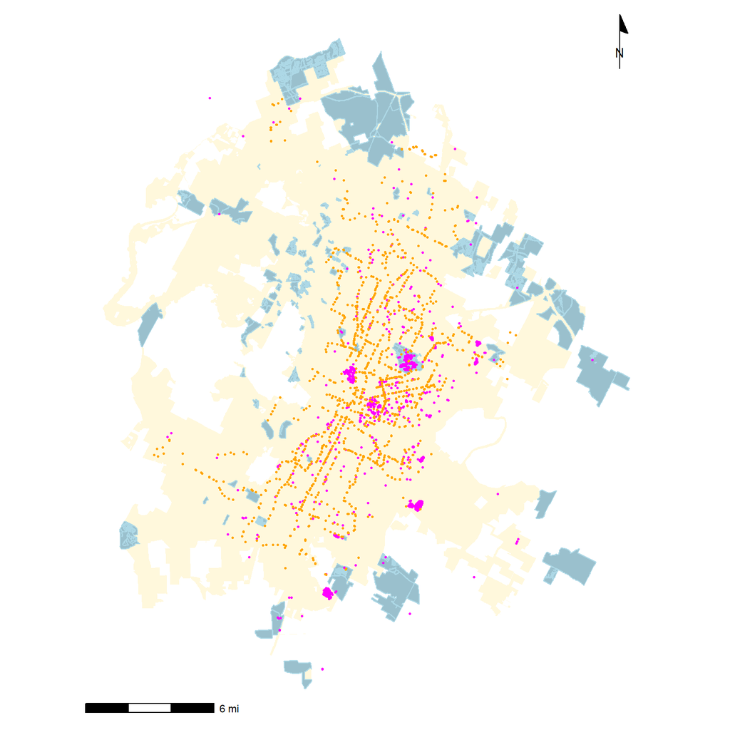

```r
ggplot(Council2) +
  geom_sf(fill = "cornsilk", color = NA) +
  geom_sf(data = PUDs2, color = "lightblue", fill = "lightblue3") +
  geom_sf(data = Afford2, color = "magenta", size = 0.5) +
  geom_sf(data = CMTA2, color = "orange", size = 0.5) +
  theme_map() +
  annotation_scale(unit_category = "imperial") +
  annotation_north_arrow(location = "tr",
                         style = north_arrow_minimal())
```

## Metrics

### 1. The number and proportion of affordable housing developments within a specified distance of transit stops

First, I will establish a “buffer” around all of the Capital Metro transit stops within the City of Austin. I set this buffer at 400 meters, as a cursory Google search revealed this to be one fairly-accepted standard for a 5-minute walking distance.

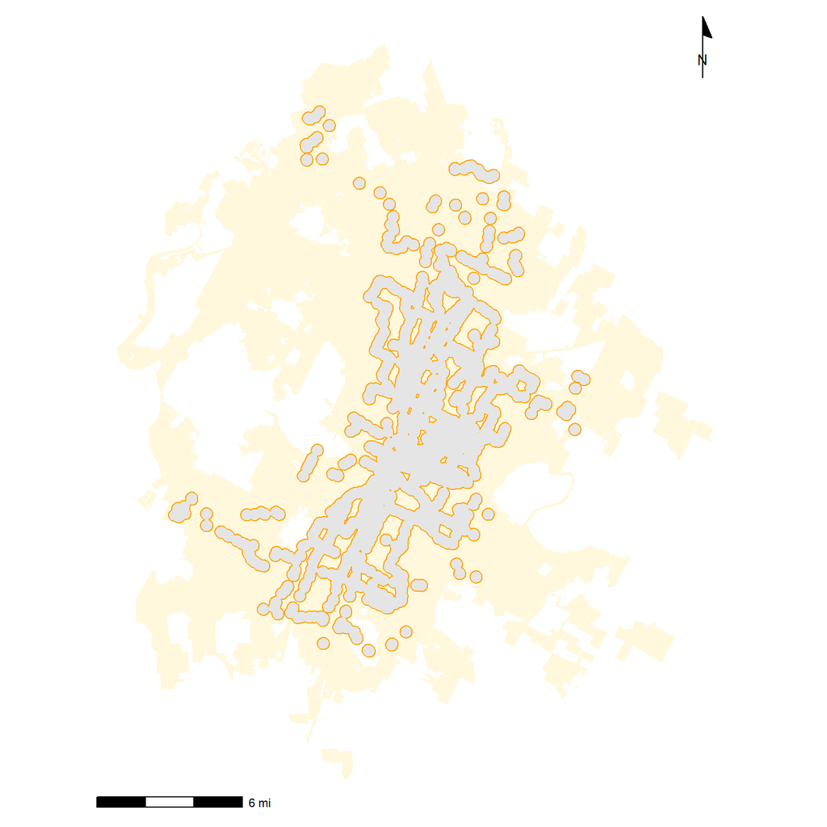

```r
CMTA2_buffer <- st_buffer(CMTA2, dist = 400) %>%
  st_union()

ggplot(Council2) +
  geom_sf(fill = "cornsilk", color = NA) +
  geom_sf(data = CMTA2_buffer, color = "orange") +
  theme_map() +
  annotation_scale(unit_category = "imperial") +
  annotation_north_arrow(location = "tr",
                         style = north_arrow_minimal())
```

Next I create a new data frame called **“afford_cmta”** which includes those of affordable housing developments (in magenta) which fall within the 400-meter transit buffer.

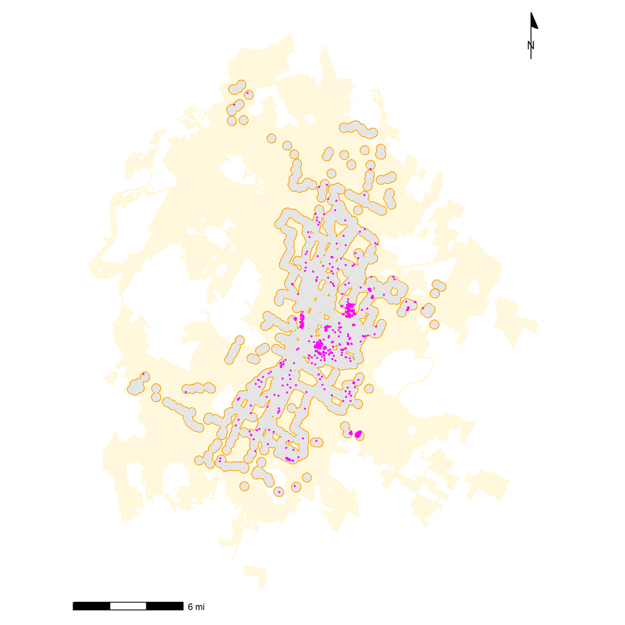

```r
afford_cmta <- Afford2[CMTA2_buffer,]

ggplot(Council2) +
  geom_sf(fill = "cornsilk", color = NA) +
  geom_sf(data = CMTA2_buffer, color = "orange") +
  geom_sf(data = afford_cmta,
          color = "magenta",
          size = 0.5) +
  theme_map() +
  annotation_scale(unit_category = "imperial") +
  annotation_north_arrow(location = "tr",
                         style = north_arrow_minimal())
```

After visualizing these locations, I want to see the number and percentage of affordable developments within the 400-meter buffer. Before calculating these values, I further clean the **“Afford2”** data frame to remove duplicate values, as this originally caused a major error in the code. Kristy helped me to figure out what was causing this problem, and provided the “st_intersection” function as a solution.

```r
Afford2 <- Afford2 %>%
  st_join(afford_cmta) %>%
  mutate(by_cmta = !is.na(Project_ID.y)) %>%
  st_intersection()
```

First, the number:

```r
n_afford_cmta <- sum(Afford2$by_cmta)

n_afford_cmta
```

```
## [1] 939
```

And the percent share:

```r
n_afford <- nrow(Afford2)

pct_cmta_afford <- n_afford_cmta / n_afford

pct_cmta_afford*100
```

```
## [1] 61.01365
```

There are 939 affordable housing developments in Austin within 400 meters of a transit stop - this represents 61% of the total number of affordable housing developments (1539, after removing duplicate entries).

### 2. Average distance between affordable housing developments and their nearest respective transit stops

```r
Afford2 <- Afford2 %>%
  mutate(CMTA_dist = st_nn(Afford2, CMTA2,
                           returnDist = TRUE)$dist) %>%
  mutate(CMTA_dist = as.numeric(CMTA_dist))
avg_CMTA_dist <- mean(Afford2$CMTA_dist)

avg_CMTA_dist
```

```
## [1] 521.6166
```

This relationship is plotted below, where I colorize the affordable housing development symbols by their distance from a transit stop.

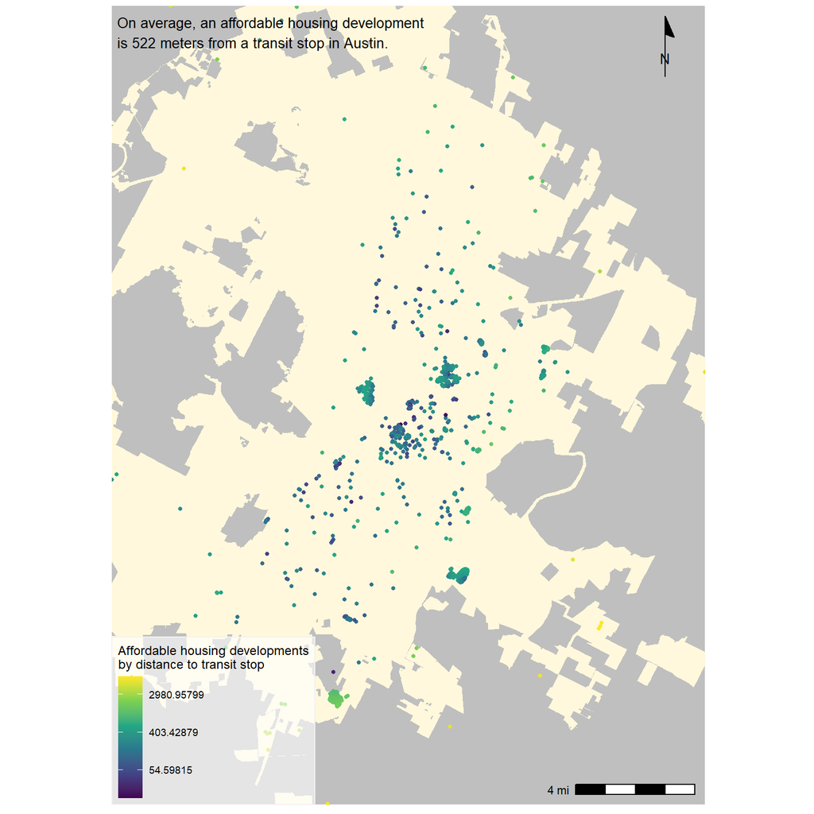

```r
right_side <- st_bbox(Afford2)$xmax
left_side  <- st_bbox(Afford2)$xmin
top_side <- st_bbox(Afford2)$ymax
bottom_side <- st_bbox(Afford2)$ymin


ggplot(Council2) +
  geom_sf(fill = "cornsilk",
          color = NA) +
  geom_sf(data = Afford2,
          aes(color = CMTA_dist),
          size = 1) +
  coord_sf(xlim = c(left_side, right_side),
           ylim = c(bottom_side, top_side), expand = FALSE) +
  scale_color_viridis_c(trans = "log",
                        name = "Affordable housing developments\nby distance to transit stop") +
  annotate(geom = "text", x = left_side + 300,
           y = top_side - 550,
           label = paste("On average, an affordable housing development\nis ",
                         prettyNum(avg_CMTA_dist, digits = 3),
                         " meters from a transit stop in Austin.",
                         sep = ""),
           hjust = 0, vjust = 1, size = 3.5) +
  theme_map() +
  annotation_scale(unit_category = "imperial",
                   location = "br") +
  annotation_north_arrow(location = "tr",
                         style = north_arrow_minimal()) +
  theme(panel.background = element_rect(fill = "gray75",
                                        color = NA),
        legend.background = element_rect(fill = alpha("white", 0.6),
                                         color = "gray95"))
```

### 3. Number and proportion of affordable housing developments in each council district

In this section I will calculate the number and proportion of affordable housing developments located in each of Austin’s ten city council districts.

```r
Council2 <- Council2 %>%
  mutate(num_afford = lengths(st_covers(Council2, Afford2)))
```

```r
summary(Council2$num_afford)
```

```
##    Min. 1st Qu.  Median    Mean 3rd Qu.    Max.
##     4.0    13.5    42.0   153.1   288.5   468.0
```

First, I subset my data frame of affordable housing developments to include only those within the city limits of Austin - the original data frame extended slightly outside of the city limits.

This map shows the location of the city’s ten council districts, and the affordable housing developments within each one.

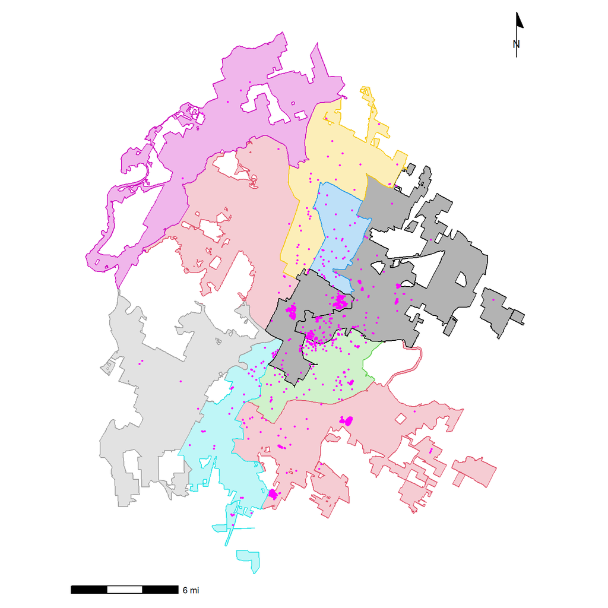

```r
afford_councils <- Afford2[Council2,]

ggplot(Council2) +
  geom_sf(fill = alpha(Council2$council_di, 0.3), color = Council2$council_di) +
  geom_sf(data = afford_councils,
          color = "magenta",
          size = 0.5) +
  theme_map() +
  annotation_scale(unit_category = "imperial") +
  annotation_north_arrow(location = "tr",
                         style = north_arrow_minimal())
```

The chloropleth map below uses the same data to colorize each council district according to its number of affordable developments - it becomes clear that the central and eastern district house more affordable housing developments than the western districts of the city.

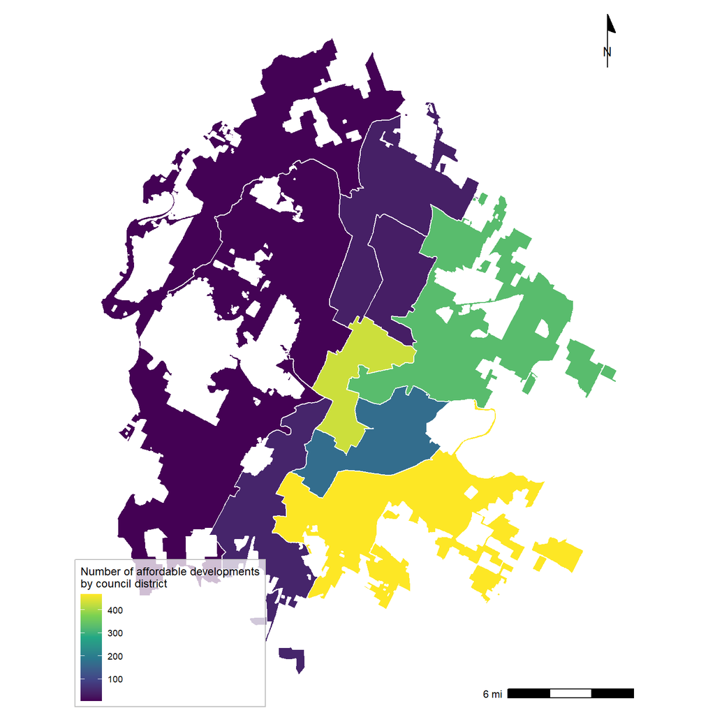

```r
ggplot(Council2) +
  geom_sf(color = "white",
          aes(fill = num_afford)) +
  scale_fill_viridis_c(name = "Number of affordable developments\nby council district",
                       breaks = breaks <- seq(0, 500, by = 100)) +
  annotation_north_arrow(location = "tr",
                         style = north_arrow_minimal()) +
  theme_map() +
  theme(legend.background = element_rect(fill = alpha("white", 0.75),
                                         color = "gray")) +
  annotation_scale(location = "br",
                   unit_category = "imperial")
```

### 4. The average density of affordable housing developments in each council district

In order to calculate the density of affordable developments in each council district, I must first find the area of each council district. I will plot the results of this density calculation on another chloropleth below.

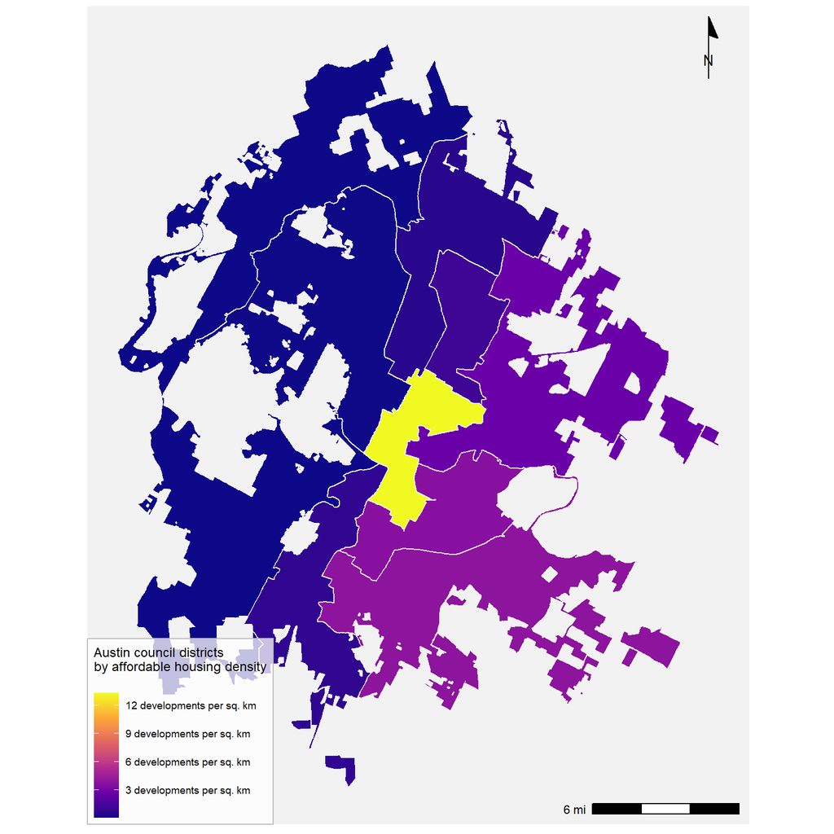

```r
Council2 <- Council2 %>%
  mutate(area = set_units(st_area(Council2), km^2)) %>%
  mutate(afford_dens = as.numeric(num_afford / area))

ggplot(Council2) +
  geom_sf(color = "gray95",
          aes(fill = afford_dens)) +
  scale_fill_viridis_c(name = "Austin council districts\nby affordable housing density\n",
                       breaks = breaks <- seq(0, 18, by = 3),
                       labels = paste(prettyNum(breaks, big.mark = ","),
                                      "developments per sq. km"),
                       option = "plasma") +
  annotation_north_arrow(location = "tr",
                         style = north_arrow_minimal()) +
  theme_map() +
  theme(legend.background = element_rect(fill = alpha("white", 0.75),
                                         color = "gray"),
        panel.background = element_rect(fill = "gray95",
                                        color = NA)) +
  annotation_scale(location = "br",
                   unit_category = "imperial")
```

```r
summary(Council2$afford_dens)
```

```
##     Min.  1st Qu.   Median     Mean  3rd Qu.     Max.
##  0.03417  0.17124  0.95402  2.60326  3.39653 13.29189
```

### 5. The average density of transit stops in each council district

Next, I repeat the process from metric #4 to determine the density of transit stops in each council district.

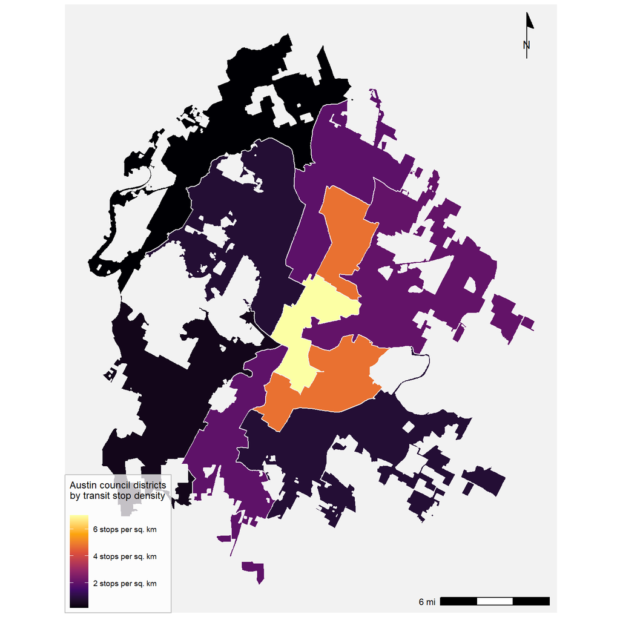

```r
Council2 <- Council2 %>%
  mutate(num_cmta = lengths(st_covers(Council2, CMTA2))) %>%
  mutate(cmta_dens = as.numeric(num_cmta / area))

ggplot(Council2) +
  geom_sf(color = "gray95",
          aes(fill = cmta_dens)) +
  scale_fill_viridis_c(name = "Austin council districts\nby transit stop density\n",
                       breaks = breaks <- seq(0, 8, by = 2),
                       labels = paste(prettyNum(breaks, big.mark = ","),
                                      "stops per sq. km"),
                       option = "inferno") +
  annotation_north_arrow(location = "tr",
                         style = north_arrow_minimal()) +
  theme_map() +
  theme(legend.background = element_rect(fill = alpha("white", 0.75),
                                         color = "gray"),
        panel.background = element_rect(fill = "gray95",
                                        color = NA)) +
  annotation_scale(location = "br",
                   unit_category = "imperial")
```

Next I print a summary of the transit stop density statistics, showing an interquartile range from 0.80 to 4.07 stops per square km, with a maximum of 7.02 per sq. km again in the central council district. In this set, the densities appear to decrease most notably with distance from the city center, in addition to reflecting the East/West divide seen in affordable housing densities.

One could infer that the western portions of the city have overall lower densities, given that they see a reduced concentration of both transit service and affordable housing.

```r
summary(Council2$cmta_dens)
```

```
##    Min. 1st Qu.  Median    Mean 3rd Qu.    Max.
##  0.1389  0.7958  1.9401  2.4553  4.0706  7.0169
```

### 6. The number and proportion of PUDs containing affordable housing developments.

Finally, I will calculate the number of PUD zoning districts in the City of Austin which contain affordable housing developments. First, a quick map illustrating where the PUDs are in the city, and the location of affordable developments located within PUDs.

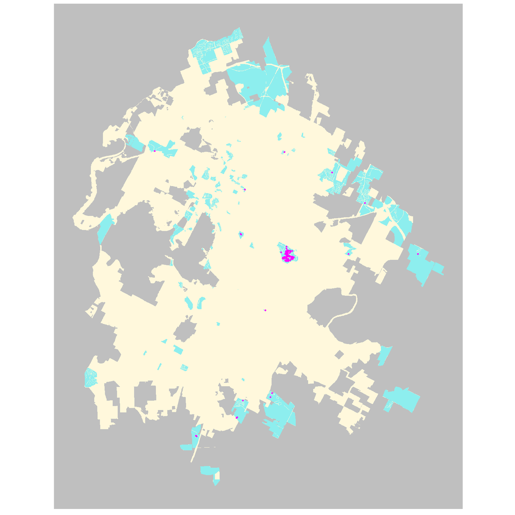

```r
afford_pud <- Afford2[PUDs2,]

ggplot(Council2) +
  geom_sf(fill = "cornsilk",
          color = NA) +
  geom_sf(data = PUDs2,
          color = NA,
          fill = "darkslategray2") +
  geom_sf(data = afford_pud,
          color = "magenta",
          size = 0.5) +
  theme_map() +
  theme(panel.background = element_rect(fill = "gray75",
                                        color = NA))
```

Next, I attach a variable to my “PUDs2” data frame which includes the number of affordable housing developments located within each PUD.

```r
PUDs2 <- PUDs2 %>%
  mutate(num_pud_afford = lengths(st_covers(PUDs2, Afford2)))
```

```r
summary(PUDs2$num_pud_afford)
```

```
##    Min. 1st Qu.  Median    Mean 3rd Qu.    Max.
##  0.0000  0.0000  0.0000  0.3544  0.0000 14.0000
```

```r
PUDs2_only_afford <- PUDs2 %>%
  filter(num_pud_afford > 0)

summary(PUDs2_only_afford$num_pud_afford)
```

```
##    Min. 1st Qu.  Median    Mean 3rd Qu.    Max.
##   1.000   2.000   3.000   3.652   5.000  14.000
```

```r
100 * (length(PUDs2_only_afford$num_pud_afford)/length(PUDs2$num_pud_afford))
```

```
## [1] 9.705562
```

Overall, approximately 9.7 percent of PUD zoning districts in Austin include affordable housing developments, or 89 out of 917 PUD zoning districts.